# Using sctransform in SCENIC AUCell (10X genomics pbmc)

Moses Apostol

2025-05-01

This vignette shows how to use the sctransform wrapper in Seurat.

Make sure the Seurat package is loaded

```r
bernoolize <- function(x) {
    stopifnot(all(x >= 0 & x <= 1))
    asin(sqrt(x))
}

remove_extended <- function(df) {
    df <- df[!grepl("extended", rownames(df)), ]
}
```

Load data and create Seurat object

```r
pbmc <- readRDS("~/Desktop/work_folder/follow-up study/human PBMC/10X_PBMC_2_10X/3.4_regulonAUC.Rds")  ## get AUC matrix
pbmc <- getAUC(pbmc)

pbmc_mtx <- remove_extended(pbmc)
pbmc <- CreateAssayObject(pbmc_mtx, key = "SCENIC")
pbmc <- CreateSeuratObject(pbmc)
```

For reference, we first apply the standard Seurat/SCENIC workflow, with log-normalization - normal gaussian

```r
pbmc_logtransform <- pbmc
pbmc_logtransform <- NormalizeData(pbmc_logtransform, verbose = FALSE)
pbmc_logtransform <- FindVariableFeatures(pbmc_logtransform, verbose = FALSE)
pbmc_logtransform <- ScaleData(pbmc_logtransform, verbose = FALSE)
pbmc_logtransform <- RunPCA(pbmc_logtransform, verbose = FALSE)
pbmc_logtransform <- RunUMAP(pbmc_logtransform, dims = 1:20, verbose = FALSE)
```

For comparison, we now apply sctransform normalization (bernollize)

```r
# Note that this single command replaces NormalizeData, ScaleData, and
# FindVariableFeatures.  Transformed data will be available in the SCT assay,
# which is set as the default after running sctransform

pbmc_mtx_norm <- bernoolize(pbmc_mtx)  ## USE FOR PCA ONLY!

# First: make the normalized assay (VST transformed, for PCA etc.)
pbmc_assay_norm <- CreateAssayObject(counts = pbmc_mtx_norm, key = "SCENIC_")

# Then: make the original AUCell assay (raw scores)
pbmc_assay_raw <- CreateAssayObject(counts = pbmc_mtx, key = "AUCell_")

# Create Seurat object with raw AUCell as the default assay
pbmc <- CreateSeuratObject(counts = pbmc_assay_raw)

# Add normalized matrix as a second assay
pbmc[["bernoolized"]] <- pbmc_assay_norm
```

## Find Variable genes rewritten for Binomial variance

We treat AUCell scores as approximate Bernoulli trials — each score reflecting the probability that a regulon is active in a given cell. The mean AUC across cells approximates the Bernoulli success probability (p), and the associated variance is naturally p(1 - p), which reflects biological heterogeneity.

```r
find_variable_genes = function(pbmc_mtx, n) {
    mean_auc <- colMeans(t(pbmc_mtx))
    expected_variance <- mean_auc * (1 - mean_auc)
    selected_regulons <- names(sort(expected_variance, decreasing = TRUE))[1:n]
    return(selected_regulons)
}
```

Rather than including all regulons, we ranked features by binomial variance $p(1 - p)$, where $p$ is the mean AUCell score per regulon. This metric captures the expected heterogeneity of activation under a Bernoulli model, peaking at intermediate activity (i.e., $p = 0.5$). We then applied a variance-stabilizing transformation $\arcsin(\sqrt{p})$ to the selected regulons to correct for heteroskedasticity and facilitate comparability across cells and conditions.

We then performed dimensional reduction by PCA and UMAP embedding.

```r
# These are now standard steps in the Seurat workflow for visualization and
# clustering
DefaultAssay(pbmc) <- "bernoolized"

pbmc <- ScaleData(pbmc, verbose = FALSE)
pbmc <- RunPCA(object = pbmc, verbose = FALSE, features = find_variable_genes(pbmc_mtx,
    43))  #pbmc_mtx is normalized
pbmc <- RunUMAP(object = pbmc, dims = 1:5, verbose = FALSE)
pbmc <- FindNeighbors(object = pbmc, dims = 1:5, verbose = FALSE)
pbmc <- FindClusters(object = pbmc, verbose = FALSE)
```

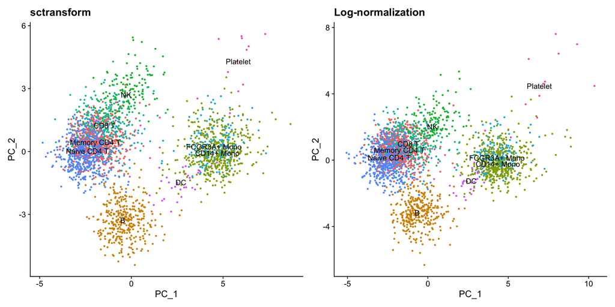

```r
## read the metadata earlier
clusterID_metadata = read.csv(file = "~/Desktop/work_folder/follow-up study/human PBMC/10X_PBMC_2_10X/metadata_pbmc_qa_qc.csv")

pbmc_logtransform$labels <- clusterID_metadata$labels
pbmc$labels = clusterID_metadata$labels
Idents(pbmc_logtransform) <- "labels"
Idents(pbmc) = "labels"

plot1 <- DimPlot(object = pbmc, label = TRUE, reduction = "pca") + NoLegend() + ggtitle("sctransform")
plot2 <- DimPlot(object = pbmc_logtransform, reduction = "pca", label = TRUE)
plot2 <- plot2 + NoLegend() + ggtitle("Log-normalization")
plot1 + plot2
```

Visualize the clustering results UMAP on the sctransform and log-normalized embedding.

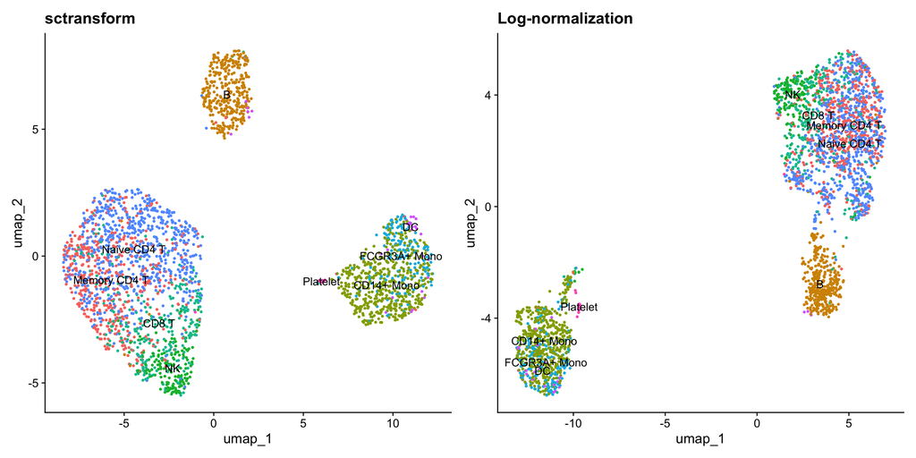

```r
pbmc_logtransform$labels <- clusterID_metadata$labels
pbmc$labels = clusterID_metadata$labels
Idents(pbmc_logtransform) <- "labels"
Idents(pbmc) = "labels"

plot1 <- DimPlot(object = pbmc, label = TRUE) + NoLegend() + ggtitle("sctransform")
plot2 <- DimPlot(object = pbmc_logtransform, label = TRUE)
plot2 <- plot2 + NoLegend() + ggtitle("Log-normalization")
plot1 + plot2
```

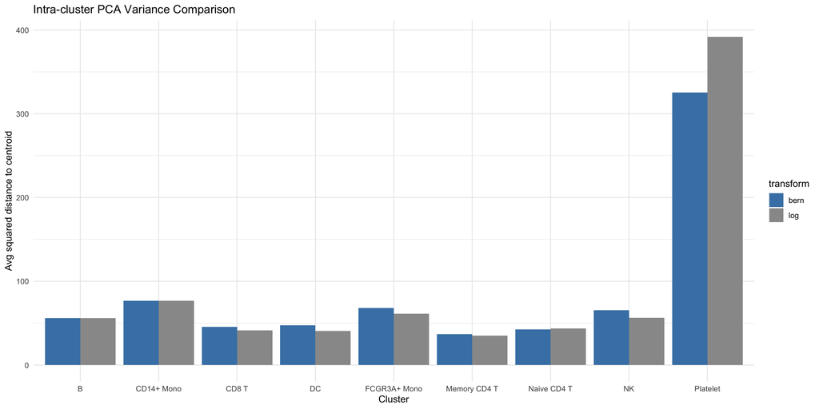

```r
# Step 1: Extract PCA embeddings from both Seurat objects
pca_log <- Embeddings(pbmc_logtransform, "pca")
pca_bern <- Embeddings(pbmc, "pca")

# Step 2: Get cluster assignments (assuming same clustering)
clusters <- Idents(pbmc_logtransform)  # or pbmc_bern if clusters are the same

# Step 3: Compute intra-cluster variance for each
compute_intra_var <- function(pca_coords, cluster_ids) {
    tapply(1:nrow(pca_coords), cluster_ids, function(idx) {
        mean(rowSums((pca_coords[idx, ] - colMeans(pca_coords[idx, , drop = FALSE]))^2))
    })
}

intra_var_log <- compute_intra_var(pca_log, clusters)
intra_var_bern <- compute_intra_var(pca_bern, clusters)

# Step 4: Plot side-by-side barplot
df_plot <- data.frame(cluster = names(intra_var_log), log = unlist(intra_var_log),
    bern = unlist(intra_var_bern))

library(tidyr)
df_long <- pivot_longer(df_plot, cols = c("log", "bern"), names_to = "transform",
    values_to = "variance")

library(ggplot2)
ggplot(df_long, aes(x = cluster, y = variance, fill = transform)) + geom_bar(stat = "identity",
    position = "dodge") + theme_minimal() + labs(title = "Intra-cluster PCA Variance Comparison",
    y = "Avg squared distance to centroid", x = "Cluster") + scale_fill_manual(values = c(log = "gray60",
    bern = "steelblue"))
```